# BST260 Final Project RMarkdown

## Regression

After having some general ideas about our dataset, we would like to make statistical models about customers’ revenue. Since our dataset is too large, we would like to have a truncated dataset by filtering the original dataset to avoid long runtimes and computer crashing.

Here, we are interested in the condition in the United States.

```r
revenue_us <- train %>%
  select(c(channelGrouping, date,
           fullVisitorId, sessionId, visitId,
           visitNumber, visitStartTime,
           isMobile, deviceCategory, hits, browser, source,
           continent, subContinent, country, region, metro, city,
           transactionRevenue)) %>%
  filter(country == "United States")

write.csv(x = revenue_us, file = "revenue_us.csv")
```

The outcome Y in our study is the continuous customer revenue, and we would like to do predictions about it based on customers’ characteristics.

```r
str(revenue_us)
```

```
## 'data.frame':    364744 obs. of  19 variables:
##  $ channelGrouping   : chr  "Referral" "Referral" "Paid Search" "Referral" ...
##  $ date              : Date, format: "2016-09-02" "2016-09-02" ...
##  $ fullVisitorId     : chr  "3746051970600816343" "2486407044795377188" "2870162892603227525" "1467563877243766337" ...
##  $ sessionId         : chr  "3746051970600816343_1472843059" "2486407044795377188_1472830426" "2870162892603227525_1472858877" "1467563877243766337_1472873256" ...
##  $ visitId           : num  1.47e+09 1.47e+09 1.47e+09 1.47e+09 1.47e+09 ...
##  $ visitNumber       : num  2 1 1 1 1 2 2 3 4 57 ...
##  $ visitStartTime    : num  1.47e+09 1.47e+09 1.47e+09 1.47e+09 1.47e+09 ...
##  $ isMobile          : logi  FALSE FALSE TRUE TRUE FALSE FALSE ...
##  $ deviceCategory    : chr  "desktop" "desktop" "mobile" "tablet" ...
##  $ hits              : int  1 1 1 1 1 1 1 1 1 1 ...
##  $ browser           : chr  "Chrome" "Chrome" "Chrome" "Safari" ...
##  $ source            : chr  "sites.google.com" "siliconvalley.about.com" "google" "siliconvalley.about.com" ...
##  $ continent         : chr  "Americas" "Americas" "Americas" "Americas" ...
##  $ subContinent      : chr  "Northern America" "Northern America" "Northern America" "Northern America" ...
##  $ country           : chr  "United States" "United States" "United States" "United States" ...
##  $ region            : chr  "California" "not available in demo dataset" "not available in demo dataset" "not available in demo dataset" ...
##  $ metro             : chr  "San Francisco-Oakland-San Jose CA" "not available in demo dataset" "not available in demo dataset" "not available in demo dataset" ...
##  $ city              : chr  "Mountain View" "not available in demo dataset" "not available in demo dataset" "not available in demo dataset" ...
##  $ transactionRevenue: num  NA NA NA NA NA NA NA NA NA NA ...
```

The column “hits” is a continuous variable that provides a record of all page visits for the customer, and “isMobile” is a categorical variable that indicates whether the customer used a mobile device to access the Store. First, we want to visualize the relationship between these two explanatory variables and the outcome revenue.

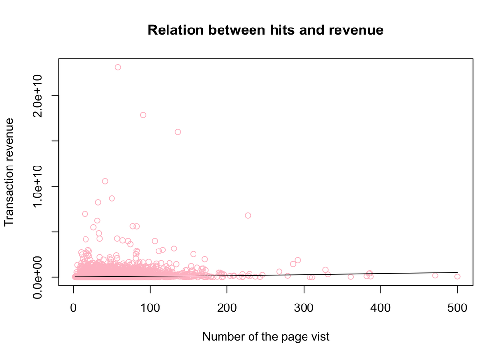

```r
scatter.smooth(revenue_us$hits, revenue_us$transactionRevenue, col="pink",
               main = "Relation between hits and revenue",
               xlab = "Number of the page vist", ylab = "Transaction revenue")
```

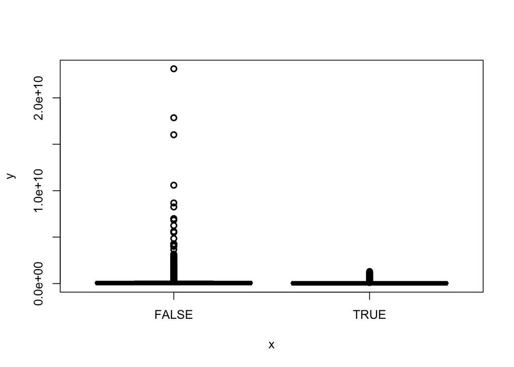

```r
plot(factor(revenue_us$isMobile), revenue_us$transactionRevenue, col="purple", lwd = 2)
```

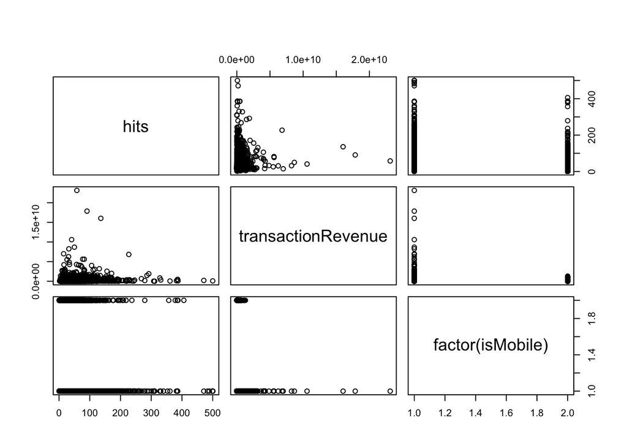

```r
pairs(~ hits + transactionRevenue + factor(isMobile), data = revenue_us, main = " ")
```

```r
# Here, we fit a simple linear model Revenue ~ Hits in accordance with the scatter plot above
lm_hits <- lm(revenue_us$transactionRevenue ~ revenue_us$hits)
summary(lm_hits)$coef
```

```
##                 Estimate Std. Error   t value     Pr(>|t|)
## (Intercept)     48356419    6964550  6.943223 4.049557e-12
## revenue_us$hits  2372023     154614 15.341574 1.418117e-52
```

The coefficient of hits is statistically significant based on this regression model, which indicates that hits is associated with the output revenue.

```r
# Redefine isMobile variable for ggplot input and run this multiple linear model
revenue_us$isMobile[revenue_us$isMobile == "TRUE"] = 1
revenue_us$isMobile[revenue_us$isMobile == "FALSE"] = 0
lm2 <- lm(transactionRevenue ~ hits + isMobile, data = revenue_us)
summary(lm2)$coef
```

```
##              Estimate Std. Error   t value     Pr(>|t|)
## (Intercept)  55753801  7135341.9  7.813753 6.058880e-15
## hits          2338729   154630.7 15.124613 3.658605e-51
## isMobile    -70833833 15141679.8 -4.678070 2.930552e-06
```

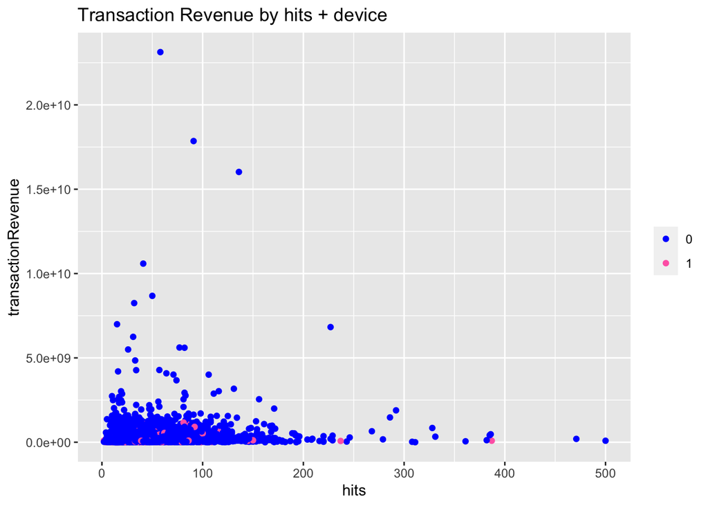

```r
# Here, we have the plot of the revenue ~ hits + device
p <- ggplot(data = revenue_us,
            aes(x = hits, y = transactionRevenue, color = factor(isMobile))) +
  geom_point() +
  ggtitle("Transaction Revenue by hits + device") +
  scale_color_manual(values = c("blue", 'hot pink')) +
  theme(legend.title = element_blank()) +
  scale_fill_manual(values = c("0", "1"), name="Access Device", breaks = c("0", "1"),
                    labels=c("Not Mobile", "Mobile"))
p
```

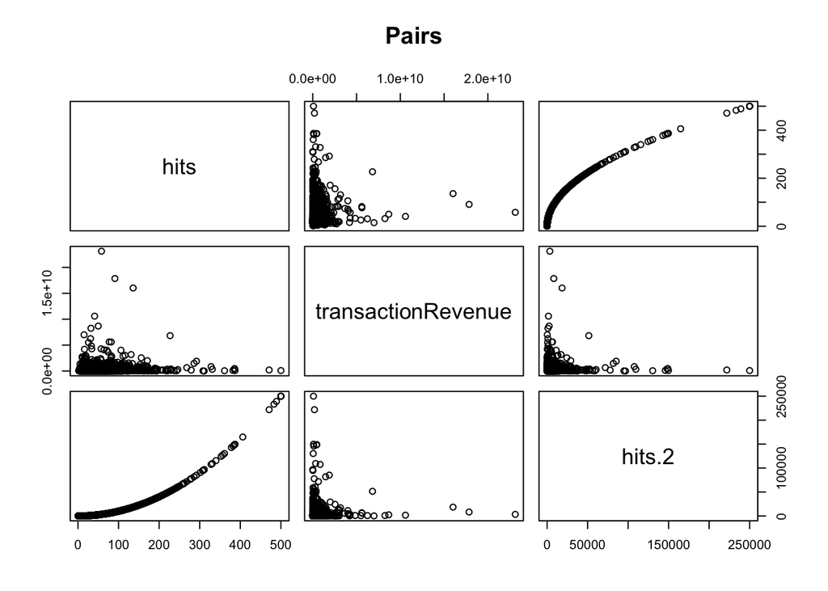

```r
# To further explore the relationship between revenue and hits, we start to consider degree polynomials
hits.2 <- I(revenue_us$hits^2)
pairs(~ hits + transactionRevenue + hits.2, data = revenue_us, main = "Pairs")
```

```r
# Fit multiple linear regression model include quadratic hits term
lm3_sq = lm(transactionRevenue ~ hits + I(hits^2) + isMobile, data = revenue_us)
tidy(lm3_sq)
```

```
## # A tibble: 4 x 5
##   term          estimate std.error statistic  p.value
##   <chr>            <dbl>     <dbl>     <dbl>    <dbl>
## 1 (Intercept)  29749164.  9033735.      3.29 9.94e- 4
## 2 hits          3394635.   273191.     12.4  3.27e-35
## 3 I(hits^2)       -5740.     1225.     -4.69 2.82e- 6
## 4 isMobile    -69162673. 15131411.     -4.57 4.91e- 6
```